# Turbofan Engine Degradation Simulation Data Set

# General information

This document contains the transcription of MathWorks MATLAB Webinar “Predictive Maintenance with MATLAB: A Prognostic Case Study” by Adam Filion, which is availabe on https://de.mathworks.com/videos/predictive-maintenance-with-matlab-a-prognostics-case-study-118661.html and https://www.youtube.com/watch?v=9QUM5jtB0t4.

The case study hass been written R.

Additional demo files can be found on * https://de.mathworks.com/matlabcentral/fileexchange/63012-demo-files-for-predictive-maintenance?focused=7812208&tab=function. * https://de.mathworks.com/matlabcentral/fileexchange/63012-demo-files-for-predictive-maintenance?focused=7812210&tab=example * https://gallery.cortanaintelligence.com/Experiment/Predictive-Maintenance-Step-1-of-3-data-preparation-and-feature-engineering-2 * https://github.com/hankroark/Turbofan-Engine-Degradation/blob/master/models/Turbofan-Degradation-DataSet-FD001.ipynb

# Description

Engine degradation simulation was carried out using C-MAPSS. Four different were sets simulated under different combinations of operational conditions and fault modes. Records several sensor channels to characterize fault evolution. The data set was provided by the Prognostics CoE at NASA Ames.

Reference: A. Saxena, K. Goebel, D. Simon, and N. Eklund, “Damage Propagation Modeling for Aircraft Engine Run-to-Failure Simulation”, in the Proceedings of the Ist International Conference on Prognostics and Health Management (PHM08), Denver CO, Oct 2008.

https://ti.arc.nasa.gov/tech/dash/pcoe/prognostic-data-repository/

We’ve acquired a fleet of 100 aircraft engines. The manufacturer recommends that we perform maintenance after every 125 flights. After our first round of maintenance, our maintenance workers tell us that only engines 39, 57, 70, and 91 were badly in need of maintenance. The others seemed fine and could have run longer without servicing. This means we are wasting money by doing maintenance more often than needed. We’d like to develop a better way to identify when servicing is needed so we can be smarter about scheduling our maintenance.

# Read in first engine data

The data used is the sensor readings taken off of the equipment. Maintenance was done after 125 flights, regardless of wheather the equipment seemed to need it or not, so we only have the 125 flights off of each engine. We have data from 100 engines, each stored in a spearate file. We’ll start by looking at just one data file for engine 1.

```r
column_names <- c(
  'Unit',
  'Time',
  'Setting1',
  'Setting2',
  'Setting3',
  'FanInletTemp',
  'LPCOutletTemp',
  'HPCOutletTemp',
  'LPTOutletTemp',
  'FanInletPres',
  'BypassDuctPres',
  'TotalHPCOutletPres',
  'PhysFanSpeed',
  'PhysCoreSpeed',
  'EnginePresRatio',
  'StaticHPCOutletPres',
  'FuelFlowRatio',
  'CorrFanSpeed',
  'CorrCoreSpeed',
  'BypassRatio',
  'BurnerFuelAirRatio',
  'BleedEnthalpy',
  'DemandFanSpeed',
  'DemandCorrFanSpeed',
  'HPTCoolantBleed',
  'LPTCoolantBleed'
)

sensor_data <-
  read.table("CMAPSSData/train_FD001.txt",
             col.names = column_names)

engine01 <- sensor_data[sensor_data$Unit == 1, ]
engine01 <- engine01[1:125, ]

head(engine01)
```

```
##   Unit Time Setting1 Setting2 Setting3 FanInletTemp LPCOutletTemp
## 1    1    1  -0.0007   -4e-04      100       518.67        641.82
## 2    1    2   0.0019   -3e-04      100       518.67        642.15
## 3    1    3  -0.0043    3e-04      100       518.67        642.35
## 4    1    4   0.0007    0e+00      100       518.67        642.35
## 5    1    5  -0.0019   -2e-04      100       518.67        642.37
## 6    1    6  -0.0043   -1e-04      100       518.67        642.10
##   HPCOutletTemp LPTOutletTemp FanInletPres BypassDuctPres
## 1       1589.70       1400.60        14.62          21.61
## 2       1591.82       1403.14        14.62          21.61
## 3       1587.99       1404.20        14.62          21.61
## 4       1582.79       1401.87        14.62          21.61
## 5       1582.85       1406.22        14.62          21.61
## 6       1584.47       1398.37        14.62          21.61
##   TotalHPCOutletPres PhysFanSpeed PhysCoreSpeed EnginePresRatio
```

[output cut: 27 more lines]

# View subset of sensor signals

We have a total of 21 sensors for each engine. Since that’s a lot to put on the screen at once, let’s look at just the first nine sensors. We can see that some of them are flat, so they won’t be useful for understanding how the condition of the system is changing. Others need a bit of smoothin to remove some noise. The other 12 sensors we are not looking at here behave similarly.

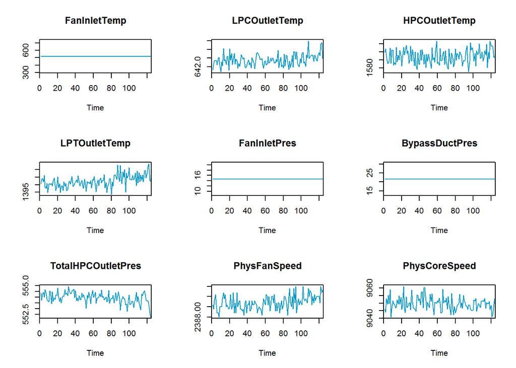

```r
view_columns <- c(
  'TotalHPCOutletPres',
  'PhysFanSpeed',
  'PhysCoreSpeed',
  'StaticHPCOutletPres',
  'FuelFlowRatio',
  'CorrFanSpeed',
  'CorrCoreSpeed',
  'BypassRatio',
  'BleedEnthalpy'
)

par(mfrow = c(3, 3))
for(ii in 1:9) {
  plot(x = engine01$Time,
       y = engine01[, 5+ii],
       type = "l",
       col = "deepskyblue3",
       xlim = c(0, 125),
       xaxs = "i",
       main = colnames(engine01)[5+ii],
       xlab = "Time",
       ylab = "")
}
```

# Select relevant variable names based on visualization

Here we select the variables we want to keep, getting rid of the sensors that were flat and unuseful.

```r
variable_names <- c(
  'Unit',
  'Time',
  'LPCOutletTemp',
  'HPCOutletTemp',
  'LPTOutletTemp',
  'TotalHPCOutletPres',
  'PhysFanSpeed',
  'PhysCoreSpeed',
  'StaticHPCOutletPres',
  'FuelFlowRatio',
  'CorrFanSpeed',
  'CorrCoreSpeed',
  'BypassRatio',
  'BleedEnthalpy',
  'HPTCoolantBleed',
  'LPTCoolantBleed'
)
engine01 = engine01[, variable_names]
```

# Remove noise

There is some amount of noise in the signal. There are many advanced methods in MATLAB to identify and remove noise. Here we simply use a trailing moving average t osmooth the signals slightly.

```r
k <- 4
engine01_smooth <- engine01

## Implementation of moving average with filling truncated areas
## First value remains the same
## Second to kth value is truncated, and averaged over values < k
for (i in 2:k) {
  engine01_smooth[i, 3:ncol(engine01_smooth)] <-
    apply(engine01[1:i, 3:ncol(engine01)], 2, mean)
}

for(i in (k+1):nrow(engine01_smooth)) {
  engine01_smooth[i, 3:ncol(engine01_smooth)] <-
    apply(engine01[(i-k):i, 3:ncol(engine01)], 2, mean)
}

## Remove truncated areas
engine01_smooth <- engine01_smooth[(k+2):nrow(engine01),]
head(engine01_smooth, 20)
```

```
##    Unit Time LPCOutletTemp HPCOutletTemp LPTOutletTemp TotalHPCOutletPres
## 6     1    6       642.264      1585.984      1402.760            554.226
## 7     1    7       642.330      1586.084      1401.686            554.344
## 8     1    8       642.372      1585.078      1401.040            554.262
## 9     1    9       642.326      1586.716      1399.626            554.110
## 10    1   10       642.194      1588.394      1398.474            554.028
## 11    1   11       642.230      1587.850      1398.928            554.002
## 12    1   12       642.146      1586.068      1399.404            554.038
## 13    1   13       642.248      1585.914      1399.376            553.956
## 14    1   14       642.294      1586.308      1400.248            554.114
## 15    1   15       642.438      1584.824      1400.582            554.124
## 16    1   16       642.408      1586.070      1401.354            554.004
## 17    1   17       642.512      1586.380      1401.314            553.860
## 18    1   18       642.422      1588.150      1400.372            554.012
## 19    1   19       642.310      1587.072      1400.610            553.952
```

[output cut: 69 more lines]

# Plot smoothed data

We are down to 14 sensors from 21 after removing the sensors that were constant signals. After smoothing the remaining signals, we can now see the signals we have to work with.

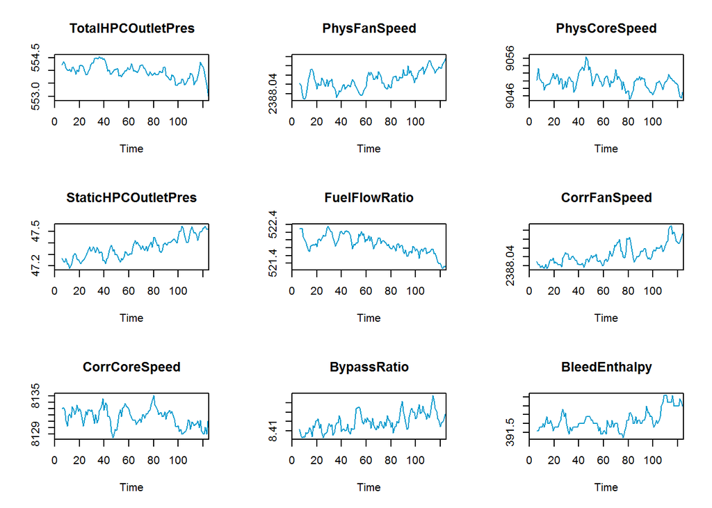

```r
par(mfrow = c(3, 3))
for(colname in view_columns) {
  plot(x = engine01_smooth$Time,
       y = engine01_smooth[, colname],
       type = "l",
       col = "deepskyblue3",
       xlim = c(0, 125),
       #ylim = c(552, 556),
       xaxs = "i",
       main = colname,
       xlab = "Time",
       ylab = "")
}
```

# Monitoring equipment - control charts

How can we use these signals to determine if the equipment is in normal conditions? One comming method is using what is called a control cart. As long as our signal stays within the upper and lower control limits, we might consdiger it normal conditions. If the signal goes outside the limits, then we might have a problem.

However when we have a large number of signals, such as the 14 we have here, it is difficult to determine when we might have a problem. Is one sensor going outside the bounds for 1 point a problem? 5 sensors for 3 points? 10 sensors for 20 points? control charts become difficult to use in these cases, so we will bring in machine learning to help us.

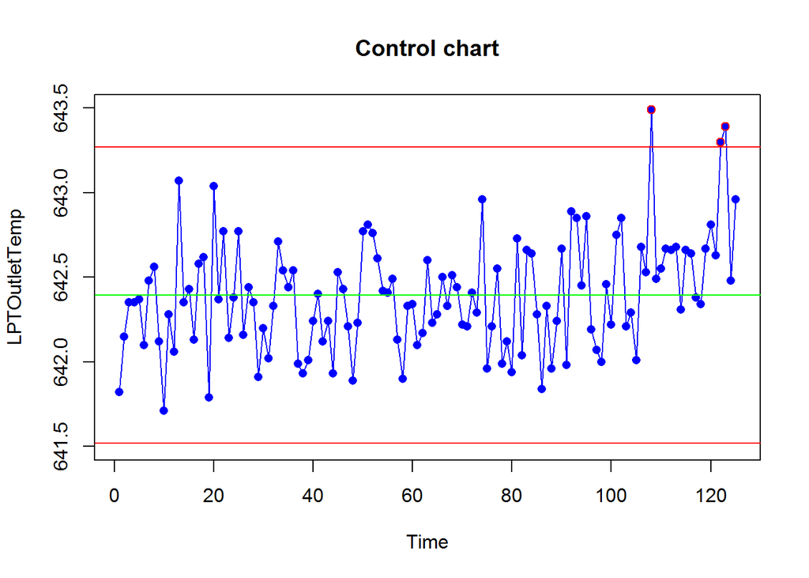

```r
## Using correction factor 1.3 when computing standard error
plot(engine01$Time, engine01$LPCOutletTemp,
     ylim = c(641.5, 643.5),
     main = 'Control chart',
     xlab = 'Time',
     ylab = 'LPTOutletTemp',
     pch = 16,
     col = "blue"
)
lines(engine01$Time, engine01$LPCOutletTemp, col = "blue")
mean_temp <- mean(engine01$LPCOutletTemp)
stderror <- sd(engine01$LPCOutletTemp)/sqrt(1.3)
ucl <- mean_temp + stderror * 3
lcl <- mean_temp - stderror * 3
abline(mean_temp, 0, col = 'green')
abline(ucl, 0, col = 'red')
abline(lcl, 0, col = 'red')
points(engine01$Time[engine01$LPCOutletTemp > ucl],
       engine01$LPCOutletTemp[engine01$LPCOutletTemp > ucl],
       col = "red")
```

# Read all data

Before we try using machine learning, let’s read in all the data we have available. Our data files are strored in a single folder, with each of the hundred engines stored in a separate file. We will use a datastore to easily read them all in.

```r
## All units already available in sensor_data
k <- 4

sensor_data_smooth <- c()
for (u in unique(sensor_data$Unit)) {
  ## Prepare data
  data_temp <- sensor_data[sensor_data$Unit == u, variable_names]
  data_temp <- data_temp[1:125,]

  data_temp_smooth <- data_temp
  ## Implementation of moving average with filling truncated areas
  ## First value remains the same
  ## Second to kth value is truncated, and averaged over values < k
  for (i in 2:k) {
    data_temp_smooth[i, 3:ncol(data_temp_smooth)] <-
      apply(data_temp[1:i, 3:ncol(data_temp)], 2, mean)
  }

  for(i in (k+1):nrow(data_temp_smooth)) {
    data_temp_smooth[i, 3:ncol(data_temp_smooth)] <-
      apply(data_temp[(i-k):i, 3:ncol(data_temp)], 2, mean)
  }

  ## remove truncated areas
  data_temp_smooth <- data_temp_smooth[(k+2):nrow(data_temp_smooth), ]
  sensor_data_smooth <- rbind(sensor_data_smooth, data_temp_smooth)
}

head(sensor_data_smooth, 10)
```

```
##    Unit Time LPCOutletTemp HPCOutletTemp LPTOutletTemp TotalHPCOutletPres
## 6     1    6       642.264      1585.984      1402.760            554.226
## 7     1    7       642.330      1586.084      1401.686            554.344
## 8     1    8       642.372      1585.078      1401.040            554.262
## 9     1    9       642.326      1586.716      1399.626            554.110
## 10    1   10       642.194      1588.394      1398.474            554.028
## 11    1   11       642.230      1587.850      1398.928            554.002
## 12    1   12       642.146      1586.068      1399.404            554.038
## 13    1   13       642.248      1585.914      1399.376            553.956
## 14    1   14       642.294      1586.308      1400.248            554.114
## 15    1   15       642.438      1584.824      1400.582            554.124
##    PhysFanSpeed PhysCoreSpeed StaticHPCOutletPres FuelFlowRatio
## 6      2388.062      9050.264              47.266       522.286
## 7      2388.058      9053.276              47.240       522.294
## 8      2388.042      9050.848              47.234       522.304
```

[output cut: 29 more lines]

# Plot all data

Now we can visualize all 100 eninges plotted on top of each other. We can now see that there is not a clear signal over time, but rather a range of values that the sensors could take.

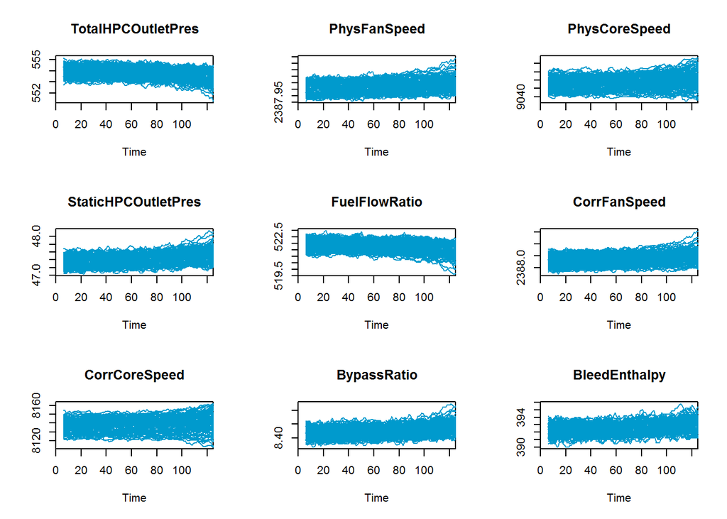

```r
par(mfrow = c(3, 3))
for (colname in view_columns) {
  plot(x = sensor_data_smooth[sensor_data_smooth$Unit == 1, "Time"],
       y = sensor_data_smooth[sensor_data_smooth$Unit == 1, colname],
       type = "l",
       xaxs = "i",
       col = "deepskyblue3",
       xlim = c(0, 125),
       ylim = c(min(sensor_data_smooth[, colname], na.rm = T),
                max(sensor_data_smooth[, colname], na.rm = T)),
       main = colname,
       xlab = "Time",
       ylab = "")

  for (u in unique(sensor_data_smooth$Unit)) {
    lines(x = sensor_data_smooth[sensor_data_smooth$Unit == u, "Time"],
          y = sensor_data_smooth[sensor_data_smooth$Unit == u, colname],
          col = "deepskyblue3")
  }
}
```

# Standardize data

Many machine learning techniques, such as PCA involve measuring distances between points. However machine learning algorithms do not understand concepts like units. Since the data is recorded with different scales and units we need to standardize the data in some way. There are many different ways we might standardize data based on its propoerties and our analysis goals. Just as one example, here we give each signal the same mean of zero and standard deviation of one.

```r
## Pull out just the sensor data, ignoring the unit and timestamp
xtrain <- sensor_data_smooth[, 3:ncol(sensor_data_smooth)]

## Give all sensors mean of zero and standard deviation of one
# xtrain_mean <- apply(xtrain, 2, mean)
# xtrain_sd <- apply(xtrain, 2, sd)
# xtrain_standard <- (xtrain - xtrain_mean) / xtrain_sd
xtrain_standard <- apply(xtrain, 2, function(x)
 scale(x, center = T, scale = T))
#xtrain_standard <- scale(xtrain, center = T, scale = T)
# xtrain_standard <- apply(xtrain, 2, function(x)
#   (x - mean(x) ) / (sd(x) / length(x) ))
```

# Dimensionality reduction - PCA

Principal component analysis (PCA) is one of the most popular methods of reducing the dimensionality of the data by rotating our axes such that they point in the direction of maximum variance. This allows us to summarize a large proportion of the data in a smaller dimensional data set. In this case, note that the first two principal component capture a good portion of the variance in the data set but further principal components only capture a small amount of additional information.

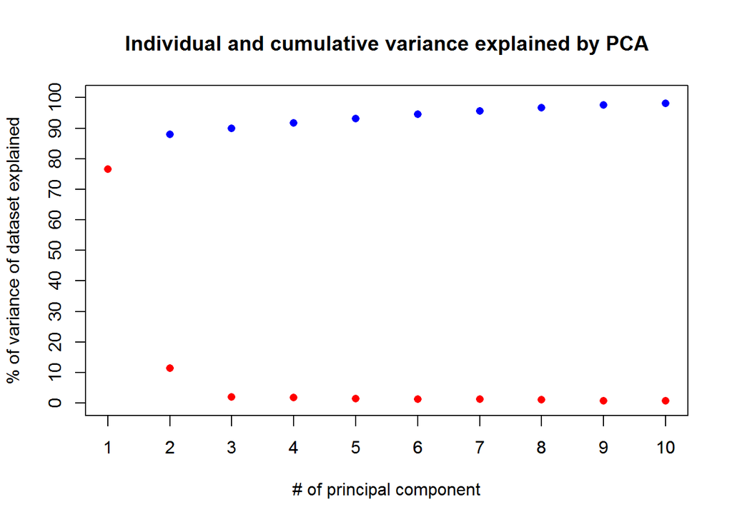

```r
## Apply principal components analysis to the standardized data
## MATLAB's pca uses singular value decomposition (SVD)
## ... so R prcomp is appropriate (vs. princomp, which uses spectral decomposition)
#pca <- prcomp(xtrain_standard)
pca <- prcomp(xtrain_standard, center = F, scale = F)
#pca <- prcomp(xtrain, center = T, scale = T)
pca_summary <- summary(pca)

## prcomp(xtrain_standard)[1] == princomp(xtrain_standard, cor = T)[1]

## Plot the total variance explained by each individual principal component
## ... along with the cumulative total that has been explained
plot(pca_summary$importance[3, 1:10] * 100,
# plot(cumsum(pca_summary$importance[2, 1:10])/sum(pca_summary$importance[2, ]) * 100,
     pch = 16, col = 'blue',
     ylim = c(0, 100),
     main = 'Individual and cumulative variance explained by PCA',
     xlab = "# of principal component",
     ylab = '% of variance of dataset explained')
axis(side = 1, at = 1:10)
axis(side = 2, at = seq(0, 100, 10))
points(pca_summary$importance[2, 1:10] * 100, pch = 16, col = 'red')
```

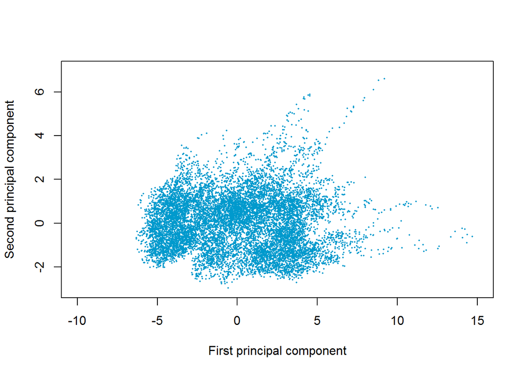

```r
# points(pca_summary$importance[2, 1:10]/sum(pca_summary$importance[2, ]) * 100, pch = 16, col = 'red')

## Visualize the first 2 principal components
## ... which explain nearly 90% of the overall variance
plot(pca$x[,1], pca$x[,2],
     pch = 16,
     cex = 0.3,
     col = "deepskyblue3",
     xlim = c(-10, 15),
     ylim = c(-3, 7),
     xlab = "First principal component",
     ylab = "Second principal component")
```

```r
## Save the needed variables to standardize new data
## ...and transform it into the same PCA projection
```

# Warning system

Now we need to find some way to use this group of points to determine when conditions are deviating away from ‘normal’. A comming approach is to call the region that contains densely packed points ‘normal’ conditions, and the small number of points that fall outside of them to be ‘anormal’ and potentially in need of maintenance. We need some way to determine when an engine might transition from ‘normal’ to ‘abnormal’ behavior.

# Visualize first and last points for each engine

As a first try we can simply look at the first and last point recorded for each engine. If engines tend to start in a certain area of the PCA, but move to a different area by the time maintenance is performed, this may give us some indiciatoin of what the trens towards failure looks like.

In this case we can see that the first and last points form two groups, with the first points centered closer to the origin and the last points centered further away. However there is significant overlap between them, which would not be suprising if many engines are still behaving normally at the time maintenance was performed.

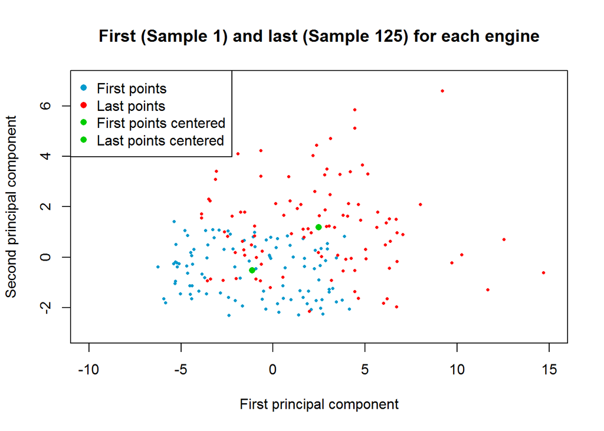

```r
## Find first and last point for each engine
idx_first <-
  vapply(unique(sensor_data_smooth$Unit),
         function(x)
           min(which(sensor_data_smooth$Unit == x)),
         numeric(1))
idx_last <-
  vapply(unique(sensor_data_smooth$Unit),
         function(x)
           max(which(sensor_data_smooth$Unit == x)),
         numeric(1))

## Compute centroids
idx_first_cent <- colMeans(pca$x[idx_first, c(1, 2)])
idx_last_cent <- colMeans(pca$x[idx_last, c(1, 2)])

## Plot data
plot(pca$x[idx_first, 1], pca$x[idx_first, 2],
     pch = 16, cex = 0.5,
     col = "deepskyblue3",
     xlim = c(-10, 15),
     ylim = c(-3, 7),
     main = 'First (Sample 1) and last (Sample 125) for each engine',
     xlab = "First principal component",
     ylab = "Second principal component")
points(pca$x[idx_last, 1], pca$x[idx_last, 2],
       pch = 16, cex = 0.5, col = "red")
points(idx_first_cent[1], idx_first_cent[2],
       pch = 16, cex = 1, col = "green3")
points(idx_last_cent[1], idx_last_cent[2],
       pch = 16, cex = 1, col = "green3")
legend("topleft",
       c("First points", "Last points",
         "First points centered", "Last points centered"),
       pch = 16, cex = 1,
       col = c("deepskyblue3", "red", "green3", "green3"))
```

# Highlight problematic engines

The prio plot showed much overlap betwen the first and last data points. However some of the last data points clearly fall well outside the main cluster. Our maintenance staff identified several engines that had showed signs of degredation. Here we can show the points just from these engines as they approach their maintenance date to see if they show any clear trends. They are plotted on top of all other points to see how they may be different.

We can see that many of them do indeed fall outside the main cluster of points, indicating that if an engine’s sensor readings move outside the main cluster it may make for a dood cirteria for when an engine needs servicing.

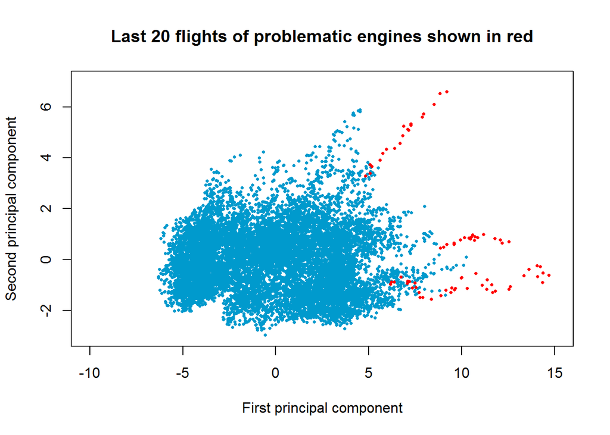

```r
idx_problematic <- sensor_data_smooth$Unit %in% c(39, 57, 70, 91)
## Only last 20 cycles
idx_problematic <-
  idx_problematic &
  sensor_data_smooth$Time > (max(sensor_data_smooth$Time) - 20)

plot(pca$x[,1], pca$x[,2],
     pch = 16,
     cex = 0.5,
     col = "deepskyblue3",
     xlim = c(-10, 15),
     ylim = c(-3, 7),
     main = "Last 20 flights of problematic engines shown in red",
     xlab = "First principal component",
     ylab = "Second principal component")
points(pca$x[idx_problematic, 1], pca$x[idx_problematic, 2],
       pch = 16, cex = 0.5, col = "red")
```

# Path through PCA

Fur further investigation we can see how different engines move through the cluster of data poings as they approach their maintenance date.

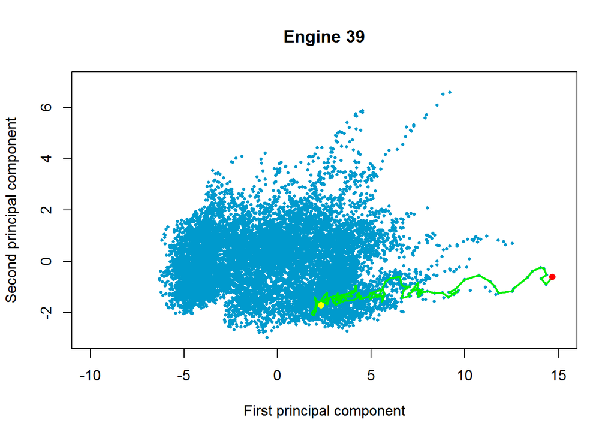

```r
# Engines identified by maintenance: 39, 57, 70, 91
engine_num = 39
r <- which(sensor_data_smooth$Unit == engine_num)
plot(pca$x[,1], pca$x[,2],
     pch = 16,
     cex = 0.5,
     col = "deepskyblue3",
     xlim = c(-10, 15),
     ylim = c(-3, 7),
     main = paste("Engine", engine_num),
     xlab = "First principal component",
     ylab = "Second principal component")
lines(pca$x[r, 1], pca$x[r, 2],
      lwd = 2, col = "green2")
points(pca$x[r[1], 1], pca$x[r[1], 2],
       pch = 16, cex = 1, col = "yellow")
points(pca$x[r[length(r)], 1], pca$x[r[length(r)], 2],
       pch = 16, cex = 1, col = "red")
```

# Inertial criteria for warning and alarm signals

Based on the results, we can make an initial guess for the criteria to use for when to issue a ‘warning’ or ‘alarm’ signal. Clearly all engines begin within the main cluster of points. It seems that they may move outside the cluster as servicing becomes more needed. We will generate a ‘warn’ result’ when the engine behavior has left ‘normal’ conditions (in this case ‘normal’ includes about 90% of the data) and should be prioritized for maintenance. An ‘alarm’ means that this engine is very far from ‘normal’ and may need maintenance urgently. Below is one example of an initial guess we may make for where to draw the line between the ‘normal’, ‘warn’ and ‘alarm’ regions.

The criteria for producing the ‘warn’ and ‘alarm’ signals should be treated as initial guesses that will continue to evolve over time as we perform more rounds of maintenance while gathering more sensor data and maintenance feedback.

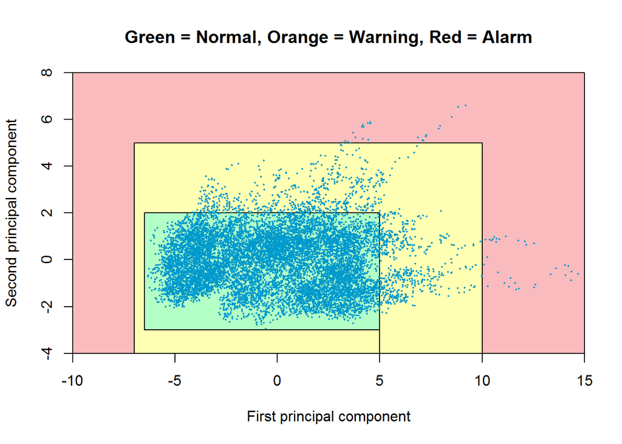

```r
idx_alarm <-
  pca$x[, 1] > 10 |
  pca$x[, 1] < -7 |
  pca$x[, 2] > 5 |
  pca$x[, 2] < -4

idx_warn <-
  pca$x[, 1] > 5 |
  pca$x[, 1] < -6.5 |
  pca$x[, 2] > 2 |
  pca$x[, 2] < -3

rectx_alarm <- c(-10, -10, 15, 15, 10, 10, -7, -7, -10)
recty_alarm <- c( -4,   8,  8, -4, -4,  5,  5, -4,  -4)

rectx_warn <- c(-7, -7, 10, 10,  5, 5, -6.5, -6.5,  4.99,  4.99, -6.5)
recty_warn <- c(-4,  5,  5, -4, -4, 2,  2,   -3,   -3,    -4,    -4)

rectx_normal <- c(-6.5, -6.5, 5,  5, -6.5)
recty_normal <- c(-3,    2,   2, -3, -3)

plot(NULL,
     xlim = c(-10, 15),
     ylim = c(-4, 8),
     xaxs = "i",
     yaxs = "i",
     main = "Green = Normal, Orange = Warning, Red = Alarm",
     xlab = "First principal component",
     ylab = "Second principal component")
polygon(rectx_alarm, recty_alarm, col = rgb(237, 28, 36, 0.3*255, maxColorValue = 255))
polygon(rectx_warn, recty_warn, col = rgb(255, 255, 0, 0.3*255, maxColorValue = 255))
polygon(rectx_normal, recty_normal, col = rgb(0, 255, 64, 0.3*255, maxColorValue = 255))
points(pca$x[,1], pca$x[,2],
     pch = 16,
     cex = 0.3,
     col = "deepskyblue3")
```

```r
cat("\n Percent of points captured by \"normal\" conditions:",
    sum(!idx_warn)/nrow(pca$x) * 100)
```

```
##
##  Percent of points captured by "normal" conditions: 90.00833
```

```r
cat("\n Percent of points captured by \"normal\" + \"warn\" conditions:",
    sum(!idx_alarm)/nrow(pca$x) * 100)
```

```
##
##  Percent of points captured by "normal" + "warn" conditions: 99.51667
```

# How can we evaluate the criteria?

Since we have never had an equiment failure, we have no way of knowing what failure looks like in the data. Even though our maintenance staff identified several engines that appeared to be degrading, and those engines appeared to show a distinct trend closer to the maintenance date, we sill don’t know how close to failure they actually were. So then how can we use this information to improve our decision making? This is one of the most difficualt aspects of unsupervised learning.

There are a number of strategies for how to use these results. Our conservative strategy is to slowly roll back the regularly scheduled maintenance dates. For example, this data came from our first round of maintenance. On the next maintenance round, we might wait to perform maintenance unteil equipment cycle 135 instead of 125, unless a piece of equipment signals an ‘alarm’. If it does, we could priotirize maintenance for that pience of equipment. Otherwise, we will wait longer that the last time to do scheduled maintenance. Along the way we can use the additional sensor data and feedback from maintenance to update our ‘warn’ and ‘alarm’ criteria.

We can continue to roll back the pace of our regularly scheduled maintenance dates, unteil we are scheduling our maintenance entirely on when we get the ‘warn’ and ‘alarm’ signals from our equipment. If a failure does occur in spite of our effors, SAVE THAT DATA! Real world data leading up to and including failure is both very valuable and very expensive to gather. The better we can understand what failure looks like in the data, the better our results can get.

# Evaluate all engines to failure

We actually do have data from all 100 engines running and failure conditions area reached, we were just ignoring what happened after sample 125 so we could explore an unsupervised workflow in a scheduled maintenance situation. Here we load in all the data from all 100 engines to determine how this would turned out if we run all our engines to failure while tracking their warning and alarm signals.

```r
library(dplyr)
```

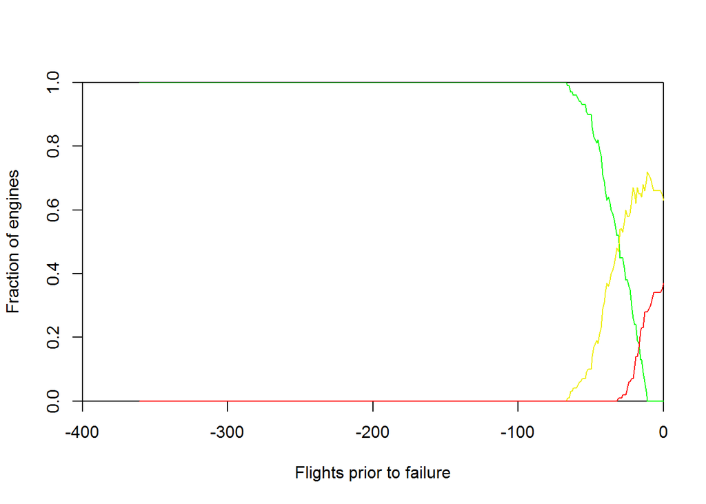

```r
## Load in full dataset
## (available in sensor_data)

## Extract and standardize full sensor data
x_full <- sensor_data[, variable_names]

x_full_smooth <- c()
## SMOOTH
for (u in unique(x_full$Unit)) {
  ## Prepare data
  data_temp <- x_full[x_full$Unit == u, variable_names]

  data_temp_smooth <- data_temp
  ## Implementation of moving average with filling truncated areas
  ## First value remains the same
  ## Second to kth value is truncated, and averaged over values < k
  for (i in 2:k) {
    data_temp_smooth[i, 3:ncol(data_temp_smooth)] <-
      apply(data_temp[1:i, 3:ncol(data_temp)], 2, mean)
  }

  for(i in (k+1):nrow(data_temp_smooth)) {
    data_temp_smooth[i, 3:ncol(data_temp_smooth)] <-
      apply(data_temp[(i-k):i, 3:ncol(data_temp)], 2, mean)
  }

  ## remove truncated areas
  #data_temp_smooth <- data_temp_smooth[(k+2):nrow(data_temp_smooth), ]
  x_full_smooth <- rbind(x_full_smooth, data_temp_smooth)
}


x_full <- x_full_smooth

x_full[, 3:ncol(x_full)] <- scale(x_full[, 3:ncol(x_full)], center = T, scale = T)
x_full <- as.data.frame(x_full)

## Project full sensor data onto prncipal coordinates
#score <- x_full[, 3:ncol(x_full)] %*% pca$rotation
score <- predict(pca, x_full[, 3:ncol(x_full)])

## Classify each point into "normal", "warning", and "alarm"
idx_alarm <-
  score[, 1] > 10 |
  score[, 1] < -7 |
  score[, 2] > 5 |
  score[, 2] < -4

idx_warn <-
  (score[, 1] > 5 |
  score[, 1] < -6.5 |
  score[, 2] > 2 |
  score[, 2] < -3) &
  !idx_alarm

idx_normal <- !idx_warn & !idx_alarm


## Group by time before failure
## ... and determine which percentage of the engines
## ... were beingt classified into each group at each point in time
#x_full$time <- sensor_data$Time
x_full$idx_normal <- idx_normal
x_full$idx_warn <- idx_warn
x_full$idx_alarm <- idx_alarm

s <-
  x_full %>%
  select(Unit, Time, idx_normal, idx_warn, idx_alarm) %>%
  group_by(Unit) %>%
  mutate(Time_max = max(Time)) %>%
  mutate(Time2 = Time - max(Time))

s_prop <-
  s %>%
  group_by(Time2) %>%
  summarise(prop_normal = sum(idx_normal)/n(),
            prop_warn = sum(idx_warn)/n(),
            prop_alarm = sum(idx_alarm)/n())

## Plot data
plot(NULL,
     xlim = c(-400, 0),
     ylim = c(0, 1),
     xaxs = "i",
     yaxs = "i",
     xlab = "Flights prior to failure",
     ylab = "Fraction of engines")
lines(s_prop$Time2, s_prop$prop_normal, col = "green")
lines(s_prop$Time2, s_prop$prop_warn, col = "yellow2")
lines(s_prop$Time2, s_prop$prop_alarm, col = "red")
```

# How much uptime did we gain?